# Women’s participation in household decision making

Diana Byanjeru

2023-12-22

## Introduction

Participation in household decision making is a key component and measure of women’s empowerment. In the Sao Tome and Principe Demographic and Health Survey (DHS) of 2008, a total of 2,615 women, currently married or in union were asked about their decision making in the household along six (6) key aspects, namely: (1) Own Health care, (2) large household purchases, (3) household purchases for daily needs, (4) Visits to family or relatives, (5) Food to be cooked each day and (6) What to do with money husband earns. The categories of decision making in the household included: (1) respondent alone, (2) respondent and husband/partner, (3) husband/partner alone, or (4) someone else.

## Findings

Figure 1 shows the distribution of respondents by selected background characteristics.

Majority of the respondents (63%) had primary level as their highest level of education completed. Less than one (1) percent of the respondents had higher than secondary level education. Respondents were almost equally distributed by wealth status with 18% in the richest quintile, and 21% in the richer and poorer quintiles. Majority of the respondents (36%) were from Regiao centro, compared to 16% from Regiao do principe. Majority of the respondents (21%) were in the age group 15-19 years. This percentage declined with increase in age group to eight (8) percent for respondents 45-49 years.

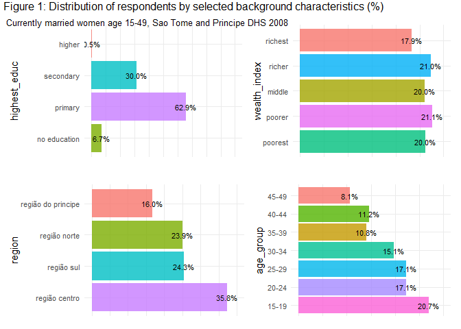

Figure 2 shows the distribution of women’s decision making on own health care by residence.

Majority of women (46% in the urban and 39% in the rural) made decisions on their own health care, together with their husband/partner. More women in the urban areas (32%) decided alone on own health care, compared to their rural counterparts (27%). In the rural areas (34%) more husbands/partners decided alone on the women’s own health care, compared to urban areas (22%). Less than one (1) percent of decision making on women’s own health care was made by someone else.

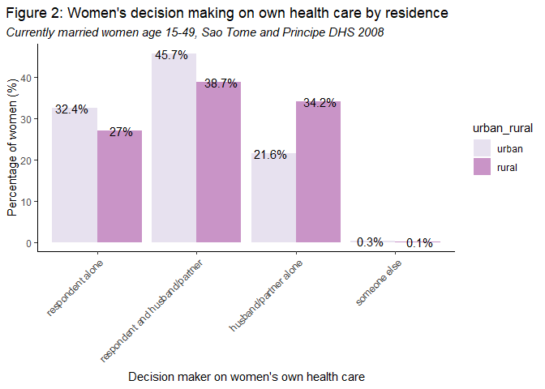

Figure 3 shows the distribution of women’s decision making on visits to family or relatives by region.

Seven in ten women (77%) in Regiao do principe decided together with their husband/partner, on visits to family or relatives. This was followed by half of the women in Regiao norte (54%) and Regiao sul (50%). Only four in ten women (44%) in Regiao centro decided together with their husband/partner on visits to family or relatives. Regiao centro (32%) had the highest percentage of women who decided alone to visit family or relatives, followed by Regiao norte (22%), and Regiao sul (16%). Only 13% of women in Regiao do principe decided alone on visits to family or relatives.

Less than 10% of women in Regiao do principe had their husband/partner decide alone for them on visits to family or relatives. Two in every ten women in Regiao norte (24%) and Regiao centro (24%) had their husband/partner decide alone for them on visits to family or relatives. Regiao sul had the highest percentage (34%) of women whose husband/partner decided alone for them on visits to family or relatives.

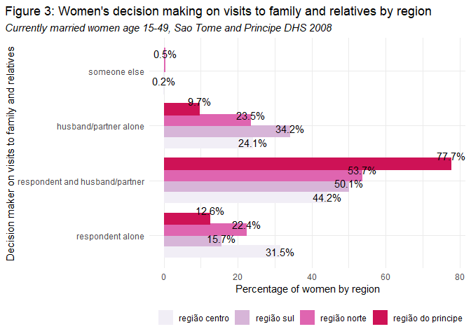

Figure 4 shows the distribution of women who participated in household decision making on at least one aspect. This has been defined as the woman’s participation in at least one aspect of decision making, either alone or with her husband/partner.

Eighty-eight percent of women participated in at least one aspect of decision making, either alone or with her husband/partner.

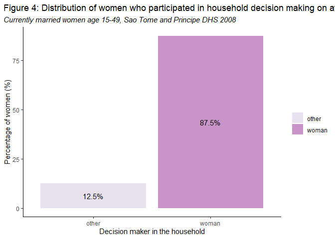

Figure 5 shows the distribution of women’s decision making in the household on at least one aspect, by highest level of education attained.

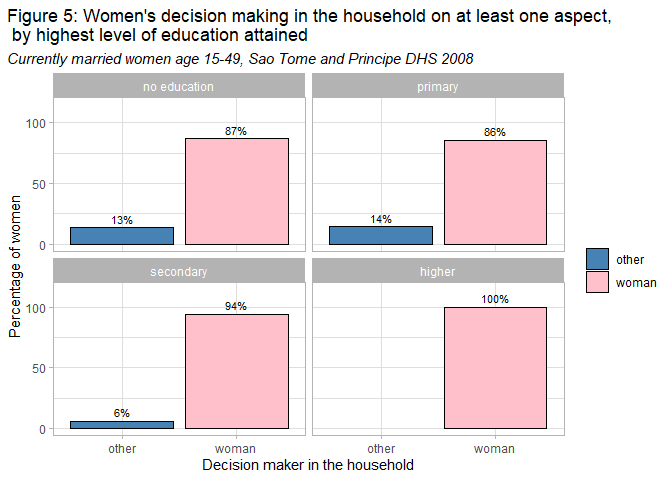

## Conclusion

Primary was the highest level of education completed by majority of the respondents, followed by secondary. Respondents were almost equally distributed by wealth status. Majority of the respondents were from Regiao centro, followed by Regiao sul and Regiao norte. The most common age group among respondents was 15-19 years.

Decision making in the household is mostly undertaken by women together their husband/partner.

Eight in ten women in Sao Tome and Principe participated in at least one aspect of decision making, either alone or with their husband/partner.

All women with higher than secondary level education participated in at least one aspect of decision making, either alone or with her husband/partner. The background characteristics of majority of the women who did not participate in decision making included lower levels of education, residence in the rural area and location in Regiao sul.